# SA3 - Assignment - 1

Satish VT

6/28/2018

```r
library(dplyr)
```

> Reading the dataset into a dataframe

```r
wildcat<-read.csv('/Users/apple/Gdrive/Term1/SA3/Assignment/wildcat.csv',header=TRUE)
```

> Question (a) - Exploration of Dataset:
- Grievances is a discrete variable (numeric count data). This is highly skewed to the right
- Rotate, Union are binary variable to describe if Rotation is allowed & if the mine is registered as a Union
- Workforce is a discrete variable (numeric count data). This variable is highly skewed to the right
- Log.workforce is a continous and normalized variable
- Wildcat.Strikes is a discrete variable (numeric count data). This variable is highly skewed to the right

```r
summary(wildcat)
```

```
##    Grievances        Rotate           Union          Workforce
##  Min.   :  0.0   Min.   :0.0000   Min.   :0.0000   Min.   :  6.0
##  1st Qu.:  0.0   1st Qu.:0.0000   1st Qu.:0.0000   1st Qu.: 55.0
##  Median :  4.0   Median :1.0000   Median :1.0000   Median :155.0
##  Mean   : 13.9   Mean   :0.5276   Mean   :0.6442   Mean   :227.4
##  3rd Qu.: 15.0   3rd Qu.:1.0000   3rd Qu.:1.0000   3rd Qu.:392.5
##  Max.   :155.0   Max.   :1.0000   Max.   :1.0000   Max.   :920.0
##  Log.workforce   Wildcat.strikes
##  Min.   :1.792   Min.   : 0.000
##  1st Qu.:4.007   1st Qu.: 0.000
##  Median :5.043   Median : 1.000
##  Mean   :4.868   Mean   : 2.509
##  3rd Qu.:5.972   3rd Qu.: 3.000
##  Max.   :6.824   Max.   :22.000
```

```r
#install.packages('e1071')
library(e1071)
skewness(wildcat$Grievances)
```

```
## [1] 2.924594
```

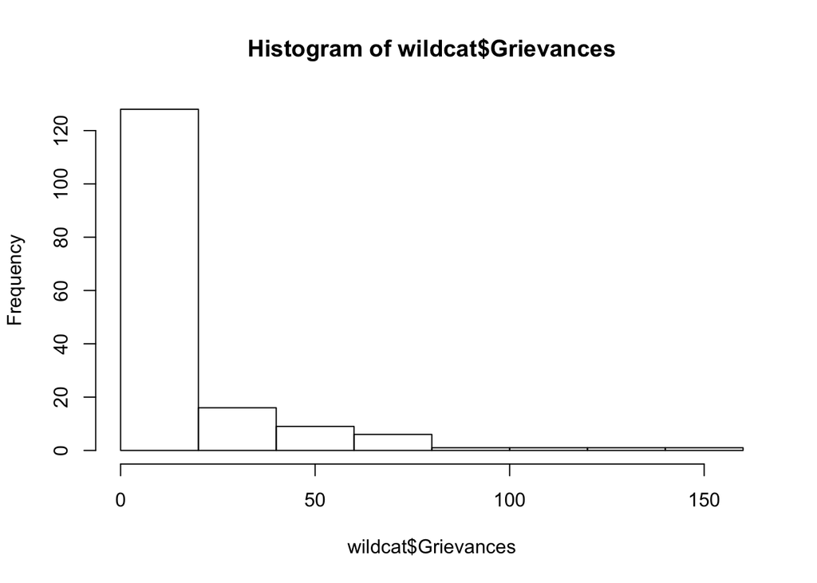

```r
hist(wildcat$Grievances)
```

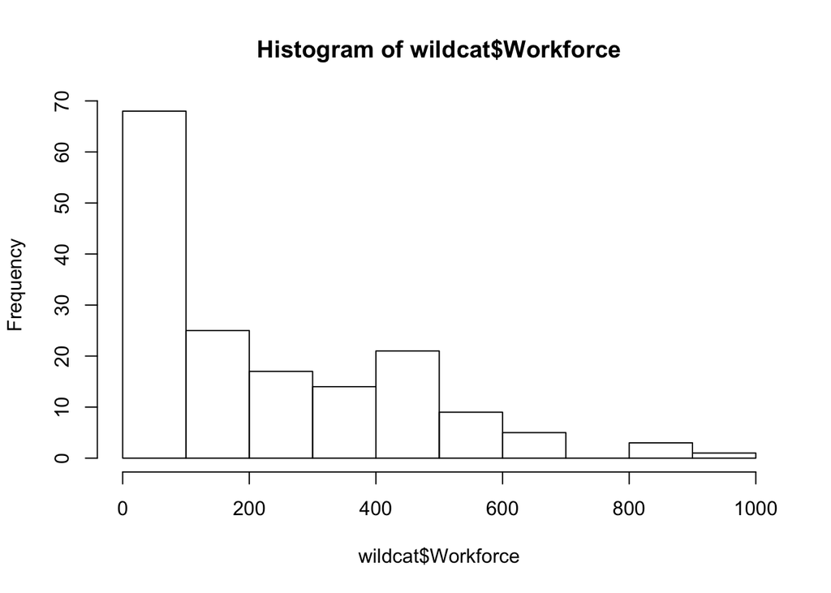

```r
hist(wildcat$Workforce)
```

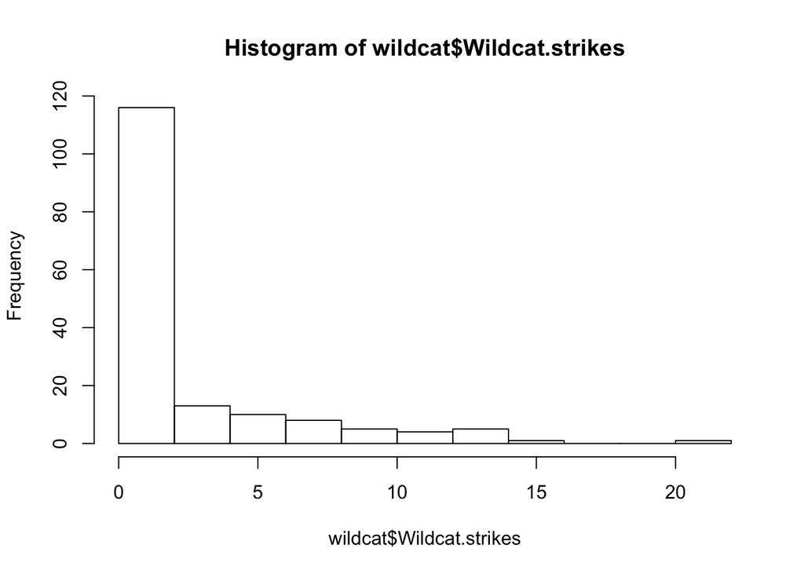

```r
hist(wildcat$Wildcat.strikes)
```